# Interaction and effect size

size matters

work in progress / enrico toffalini @ psicostat

February 21st, 2024

### Initial setup

```r
rm(list=ls())
library(ggplot2)
library(effects)
library(effsize)
rnd = function(x,digits=2){ return(format(round(x,digits),nsmall=digits)) }
load("interaction_datasets.RData")
tsz=25
```

# WHAT’S IN A “Cohen’s *f*”?

Cohen’s *f* is often used for expressing effect size in interactions. General formula for Cohen’s *f* is like this:

$$Cohen's f = \sqrt{\frac{R^2}{1 -
R^2}}$$

However, for interactions we should consider what is *added* by the interaction alone (above and beyond the main effects):

$$Cohen's f = \sqrt{\frac{R^2_1 -
R^2_0}{1 - R^2_1}}$$

Cohen’s *f* = 0.25 (about Cohen’s *f* <sup>2</sup> = 0.06) is often taken as “medium” effect size. In fact, Cohen’s *f* = 0.40 (about Cohen’s *f* <sup>2</sup> = 0.15) is also taken as “medium” sometimes. Note that Cohen’s *f* = 0.25 requires R<sup>2</sup> = 0.06, corresponding to about *r* = 0.24, while Cohen’s *f* = 0.40 requires R<sup>2</sup> = 0.15, corresponding to about *r* = 0.39. **So, it makes more sense to say that Cohen’s *f* = 0.25 is “medium”.**

Anyways… what does that mean in actual interactions? The problem is that there are infinite cases that lead to the same effect size (e.g., Cohen’s *f*) in interactions.

All examples below will present about Cohen’s *f* ≈ 0.25 (Cohen’s *f* <sup>2</sup> ≈ 0.06).

### Example: Fully crossed interaction (2 x 2)

May happen in well-designed experimental studies, but otherwise infrequent in real life (?). Here, each main effect is small or even null, and the interaction accounts for most or all explained variance.

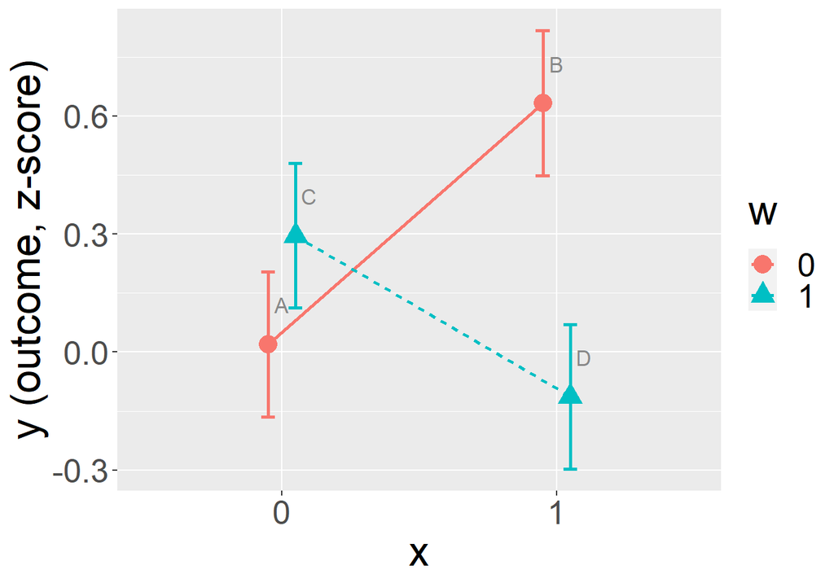

In model without interaction, R<sup>2</sup> = **`0.01`**. In model with interaction, R<sup>2</sup> = **`0.07`**.  
Overall, Cohen’s *f* = **`0.25`** (Cohen’s *f* <sup>2</sup> = **`0.06`**).

But… a simpler way to understand the above effect may be via Standardized Mean Differences (SMDs, such as Cohen’s *d*):

- the effect size (SMD) for X when W = 0 is Cohen’s *d* = **`0.65`** (cell B - A).
- the effect size (SMD) for X when W = 1 is Cohen’s *d* = **`-0.37`** (cell D - C).

### Example: Treatment-like effect (2 x 2)

Imagine a situation like a treated-vs-control-group experiment with pre-test and post-test. In one condition (w = 0) x has not effect over y, while in the other (w = 1) x has a clearly visible effect over y. The interaction coefficients tells you (as usual) the difference-between-differences across conditions.

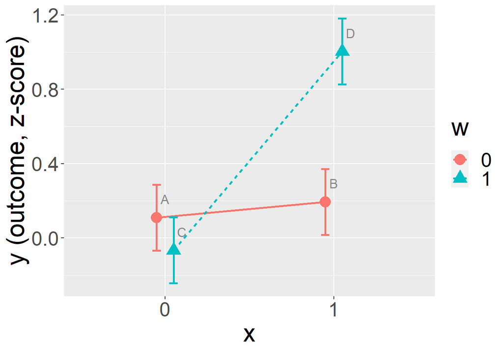

In model without interaction, R<sup>2</sup> = **`0.10`**. In model with interaction, R<sup>2</sup> = **`0.15`**.  
Overall, Cohen’s *f* = **`0.25`** (Cohen’s *f* <sup>2</sup> = **`0.06`**).

But note how much the effects must vary across conditions to get there:

- the effect size (SMD) for X when W = 0 is Cohen’s *d* = **`0.09`** (cell B - A).
- the effect size (SMD) for X when W = 1 is Cohen’s *d* = **`1.03`** (cell D - C).

…is this really a *medium* effect?! 😱

### Example: Treatment-like effect (2 x 3)

Imagine a situation like a treated-vs-control-group experiment with pre-test, post-test, and follow-up. Not much different from before, and it’s a “familiar” situation. However, there are 2 interaction coefficients here; using the default contrasts, they tell you how the difference between levels of w (e.g., groups) varies from x = “00” to x = “01” (1<sup>st</sup> interaction coefficient), and from x = “00” to x = “10” (2<sup>nd</sup> interaction coefficient).

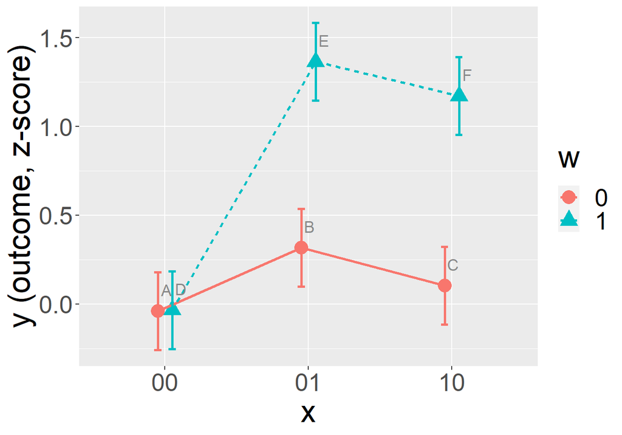

In model without interaction, R<sup>2</sup> = **`0.20`**. In model with interaction, R<sup>2</sup> = **`0.25`**.  
Overall, Cohen’s *f* = **`0.25`** (Cohen’s *f* <sup>2</sup> = **`0.06`**).

But note how much the effects must vary across conditions to get there:

- the effect size (SMD) at time x = “00” (cell D - A) is Cohen’s *d* = **`0.01`**.
- the effect size (SMD) at time x = “01” (cell E - B) is Cohen’s *d* = **`1.00`**.
- the effect size (SMD) at time x = “10” (cell F - C) is Cohen’s *d* = **`1.04`**.

…is this really a *medium* effect?! 😱

### Example: Group moderate continuous effect (2 x continuous)

Imagine studying how a relationship between x and y is different across two populations.

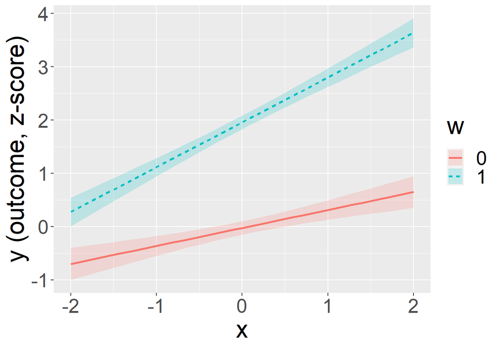

In model without interaction, R<sup>2</sup> = **`0.57`**. In model with interaction, R<sup>2</sup> = **`0.59`**.  
Overall, Cohen’s *f* = **`0.25`** (Cohen’s *f* <sup>2</sup> = **`0.06`**).

…is this really a *medium* effect?! 😱

### Example: Continuous relationship moderated by another continuous variable (continuous x continuous)

Imagine studying how a relationship between x and y is different across different levels of a continuous moderator z.

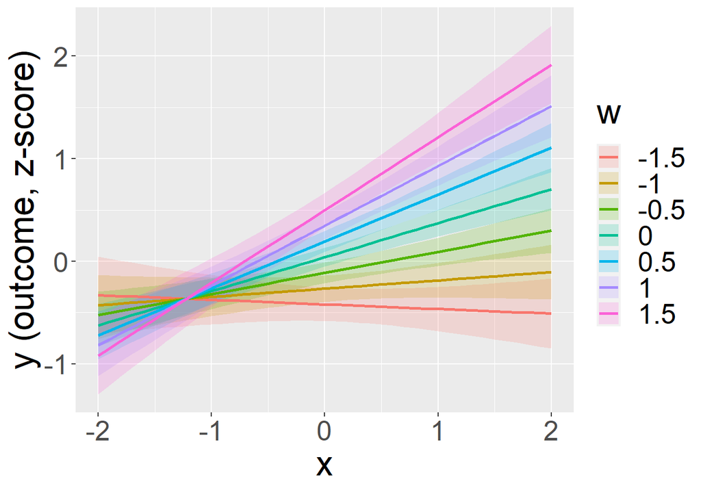

In model without interaction, R<sup>2</sup> = **`0.15`**. In model with interaction, R<sup>2</sup> = **`0.20`**.  
Overall, Cohen’s *f* = **`0.25`** (Cohen’s *f* <sup>2</sup> = **`0.06`**).

The graphical representation above, however, is a little bit messy. We could simplify that by keeping just 3 lines at interpretable points (e.g., z-score of the moderator W equal -1, 0, +1):

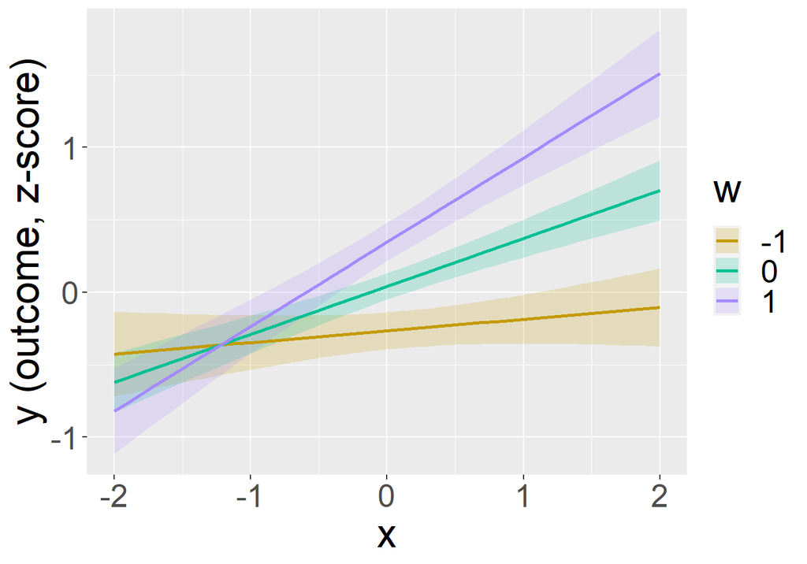

Getting the estimates of the x-y relationship at given points of w, like in the previous case, can be done by looking at the coefficient “x” in the model summary, knowing that the “x:w” coefficient means how the effect of x on y varies for every unitary +1 increase of the moderator w.

Let’s have a look at the summary:

```r
summary(fit1)
```

```
##
## Call:
## lm(formula = y ~ x * w, data = dcc)
##
## Residuals:
##     Min      1Q  Median      3Q     Max
## -3.1749 -0.6784 -0.0200  0.7015  2.7791
##
## Coefficients:
##             Estimate Std. Error t value Pr(>|t|)
## (Intercept)  0.04000    0.04648   0.861     0.39
## x            0.33167    0.04700   7.056 6.08e-12 ***
## w            0.30607    0.04717   6.489 2.18e-10 ***
## x:w          0.25116    0.04590   5.472 7.20e-08 ***
## ---
## Signif. codes:  0 '***' 0.001 '**' 0.01 '*' 0.05 '.' 0.1 ' ' 1
##
## Residual standard error: 1.016 on 476 degrees of freedom
## Multiple R-squared:  0.1976, Adjusted R-squared:  0.1925
## F-statistic: 39.07 on 3 and 476 DF,  p-value: < 2.2e-16
```

In fact, y is not really on a z-score metrics here. Its residual SD that is about 1.0. Due to the very strong effects of x, w, and their interactions, the overall SD of y is 1.13.

So, the model coefficients here cannot be easily and directly interpreted in a correlation-like fashion.

Perhaps it’s better to look at the actual standardized coefficients:

```r
lm.beta::lm.beta(fit1)
```

```
##
## Call:
## lm(formula = y ~ x * w, data = dcc)
##
## Standardized Coefficients::
## (Intercept)           x           w         x:w
##          NA   0.2910461   0.2677671   0.2260456
```